# Summary statistics of simulated variants, derived variants, and extractred ancestral sequences

2024-11-08

# Variant simulator; report

### Node used for reconstructing ancestral genome sequence

If a (newick) phylogenetic tree file has been provided, the visualisation of the MSA used in the calculations is shown below. The two chosen groups (i.e. ‘ingroup’ / species of interest, and outgroup) are highlighted in the tree. The outgroup, used in the computation or not, is the outgroup, which together with the reference species of interest coalesce at the node of interest, from which the ancestral sequence have been extracted. Most recent common ancestor (MRCA) is highlighted in purple and labeled. The rest of the clades in the alignment are shown in lighter grey. Regardless whether a reconstructed ancestral sequence at a node, or an outgroup, has been chosen as the ancestor, the MRCA will be highlighted.

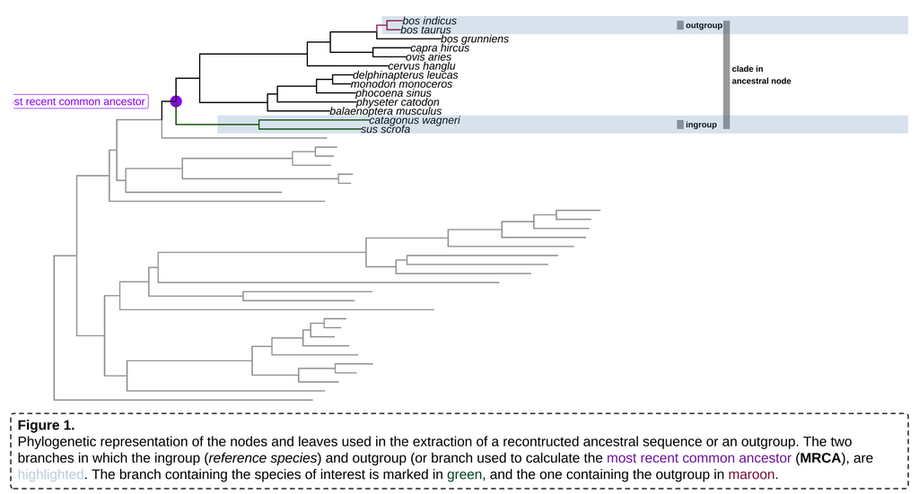

### Distribution of simulated variants across the reference genome

If an ideogram (often possible to download on the UCSC website, [here](https://genome.ucsc.edu/cgi-bin/hgTables)) has been provided, the distribution of simulated variants is shown across the genome of the species of interest. The grey distribution corresponds to the total amount of simulated variants, whereas the red distribution corresponds to the subset that is overlapping with a corresponding non-gap ancestral sequence. If there is no forced sub-sampling due to lack of ancestral sequence, the distribution will be fully red.

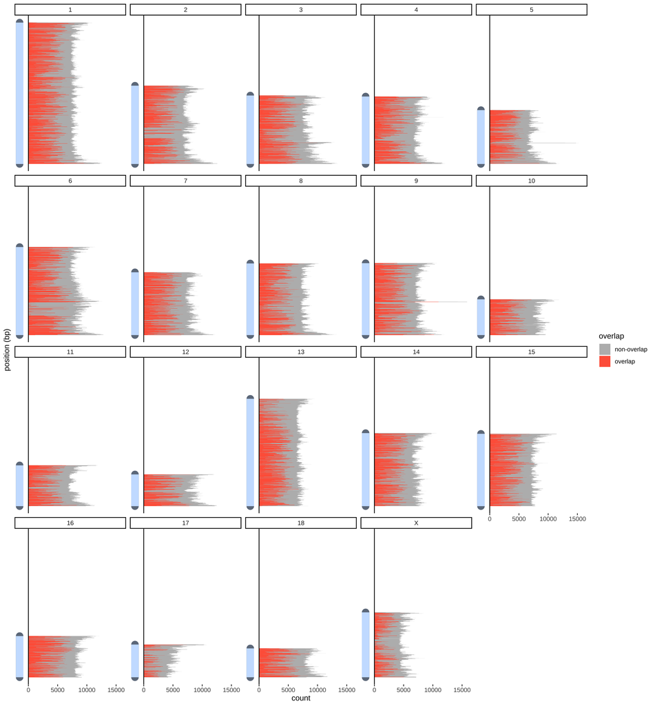

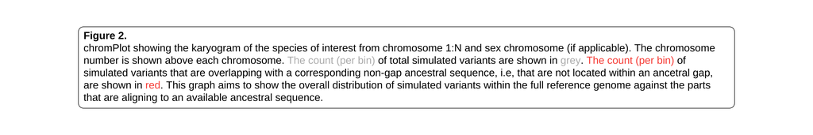

### Distribution of derived variants across the reference genome

If an ideogram (often possible to download on the UCSC website, [here](https://genome.ucsc.edu/cgi-bin/hgTables)) has been provided, the distribution of derived variants is shown across the genome of the species of interest. The distribution of derived variants across the genome is shown in red.

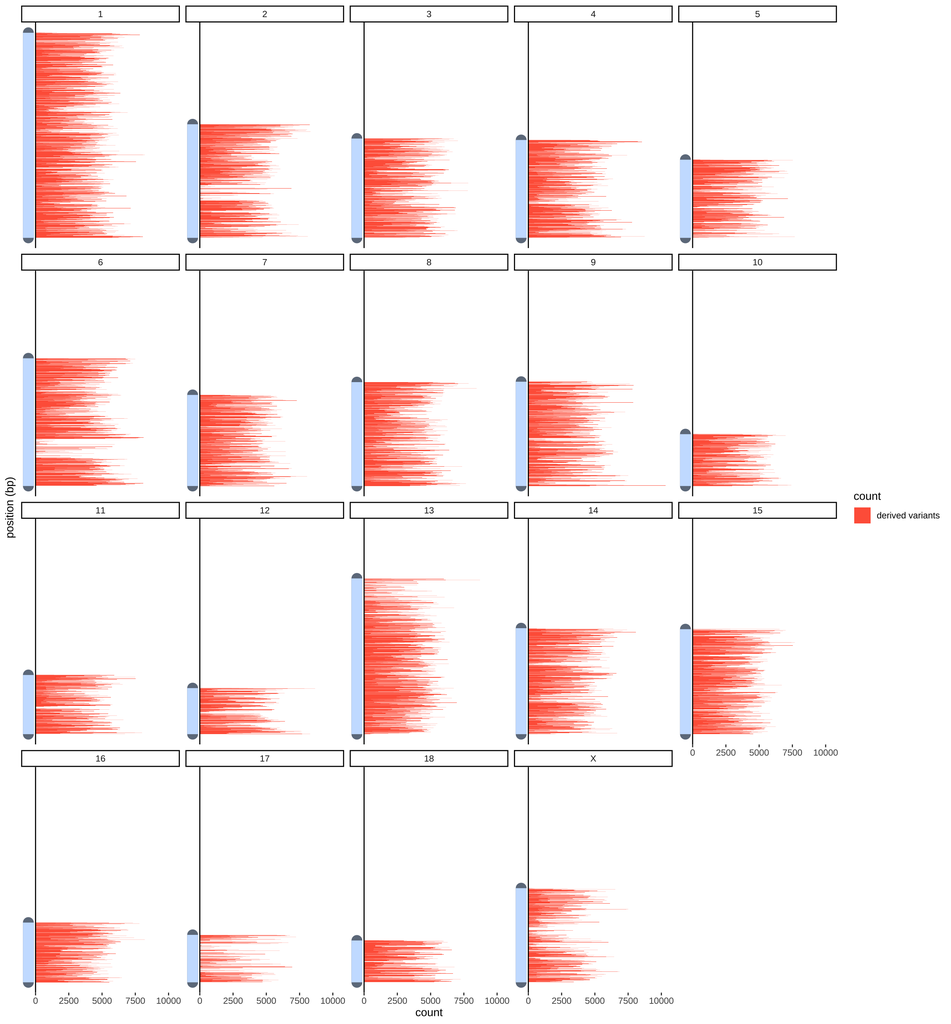

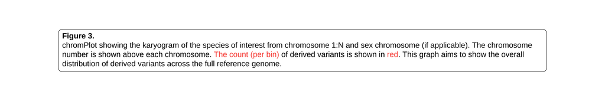

### How much of the reference genome that has an available, aligned reconstructed ancestral sequence

**Table 1** Fraction of refence genome that has an available aligned reconstructed ancestral sequence. The leftmost column represents the total size of the source chromosome (in base pairs), from the species of interest. The middle column represents the size (in base pairs) of the recontructed ancestral genome (or size of aligned outgroup without gaps). The rightmost column represents the fraction of the reference genome that is covered by an ancestral sequence, i.e. the fraction of the reference with a corresponding non-gap ancestral alignment.

|  | Size of ref. genome | Size of reconstructed genome | Fraction covered of ref. genome |
| --- | --- | --- | --- |
| 1 | 274 330 532 | 86 159 508 | 0.31 |
| 2 | 151 935 994 | 42 079 399 | 0.28 |
| 3 | 132 848 913 | 38 941 004 | 0.29 |
| 4 | 130 910 915 | 35 125 192 | 0.27 |
| 5 | 104 526 007 | 28 152 729 | 0.27 |
| 6 | 170 843 587 | 49 771 406 | 0.29 |
| 7 | 121 844 099 | 36 176 581 | 0.30 |
| 8 | 138 966 237 | 39 184 925 | 0.28 |
| 9 | 139 512 083 | 39 347 045 | 0.28 |
| 10 | 69 359 453 | 18 023 566 | 0.26 |
| 11 | 79 169 978 | 20 562 672 | 0.26 |
| 12 | 61 602 749 | 17 125 428 | 0.28 |
| 13 | 208 334 590 | 58 674 576 | 0.28 |
| 14 | 141 755 446 | 38 729 099 | 0.27 |
| 15 | 140 412 725 | 43 101 389 | 0.31 |
| 16 | 79 944 280 | 25 502 491 | 0.32 |
| 17 | 63 494 081 | 8 217 468 | 0.13 |
| 18 | 55 982 971 | 16 738 833 | 0.30 |
| X | 125 939 595 | 23 370 700 | 0.19 |

### Number of simulated variants

##### and how many are overlapping with an available ancestral sequence

[figure not shown]

##### Table with corresponding data:

**Table 2**. Fraction of simulated SNPs that is overlapping with a reconstructed ancestral sequence. Column explanation from left to right: **i)** chromosome number **ii)** the total number of simulated SNPs **iii)** the *number* of simulated SNPs that are overlapping with a non-gap align recontructed ancestral sequence. **iv)** the *fraction* of simulated SNPs that are overlapping with a non-gap align recontructed ancestral sequence. **v)** the total number of derived variants.

|  | No of sim. SNPs | Number of sim. SNPs overlapping ancestral seq. | Fraction of sim. SNPs overlapping ancestral seq. | Number of derived variants |
| --- | --- | --- | --- | --- |
| 1 | 21 510 286 | 6 788 060 | 0.32 | 6 283 119 |
| 2 | 11 528 866 | 3 217 615 | 0.28 | 3 179 750 |
| 3 | 11 366 663 | 3 355 934 | 0.30 | 3 025 293 |
| 4 | 9 916 072 | 2 673 733 | 0.27 | 2 670 223 |
| 5 | 7 690 332 | 2 031 561 | 0.26 | 2 078 453 |
| 6 | 14 255 805 | 4 132 979 | 0.29 | 3 814 374 |
| 7 | 9 818 652 | 2 895 073 | 0.29 | 2 694 127 |
| 8 | 10 875 288 | 3 094 369 | 0.28 | 3 034 273 |
| 9 | 10 840 234 | 3 061 868 | 0.28 | 3 003 488 |
| 10 | 5 899 105 | 1 534 792 | 0.26 | 1 494 533 |
| 11 | 6 225 882 | 1 633 621 | 0.26 | 1 631 502 |
| 12 | 5 401 919 | 1 512 103 | 0.28 | 1 347 813 |
| 13 | 14 385 434 | 4 038 093 | 0.28 | 4 214 175 |
| 14 | 10 334 451 | 2 826 459 | 0.27 | 2 842 089 |
| 15 | 10 643 152 | 3 253 026 | 0.31 | 3 105 298 |
| 16 | 6 846 634 | 2 193 949 | 0.32 | 1 959 793 |
| 17 | 3 230 295 | 422 904 | 0.13 | 655 900 |
| 18 | 4 892 087 | 1 471 860 | 0.30 | 1 310 988 |
| X | 6 271 200 | 1 195 934 | 0.19 | 1 649 212 |

### Types of simulated mutations

[figure not shown]

##### Table with corresponding data:

**Table 3** Fraction of mutation types across the simulated variants with an available corresponding ancestral sequence. Column explanation, starting from left: **i)** chromosome number **ii)** the total number of SNPs **iii)** the fraction of transitions **iv)** the fraction of transversions **v)** the fraction of CpG site mutations **vi)** the fraction of non-CpG mutations (transitions + transversions)

|  | No. of SNPs | Fraction transitions | Fraction transversions | Fraction CpGs | Fraction non-CpGs (1-CpGs) |
| --- | --- | --- | --- | --- | --- |
| 1 | 6 788 060 | 0.51 | 0.33 | 0.16 | 0.84 |
| 2 | 3 217 615 | 0.48 | 0.31 | 0.20 | 0.80 |
| 3 | 3 355 934 | 0.47 | 0.30 | 0.23 | 0.77 |
| 4 | 2 673 733 | 0.48 | 0.31 | 0.20 | 0.80 |
| 5 | 2 031 561 | 0.49 | 0.32 | 0.20 | 0.80 |
| 6 | 4 132 979 | 0.47 | 0.30 | 0.22 | 0.78 |
| 7 | 2 895 073 | 0.49 | 0.31 | 0.20 | 0.80 |
| 8 | 3 094 369 | 0.50 | 0.33 | 0.17 | 0.83 |
| 9 | 3 061 868 | 0.49 | 0.32 | 0.18 | 0.82 |
| 10 | 1 534 792 | 0.47 | 0.31 | 0.22 | 0.78 |
| 11 | 1 633 621 | 0.48 | 0.31 | 0.21 | 0.79 |
| 12 | 1 512 103 | 0.44 | 0.28 | 0.28 | 0.72 |
| 13 | 4 038 093 | 0.51 | 0.33 | 0.16 | 0.84 |
| 14 | 2 826 459 | 0.48 | 0.31 | 0.21 | 0.79 |
| 15 | 3 253 026 | 0.51 | 0.34 | 0.15 | 0.85 |
| 16 | 2 193 949 | 0.51 | 0.33 | 0.16 | 0.84 |
| 17 | 422 904 | 0.37 | 0.24 | 0.40 | 0.60 |
| 18 | 1 471 860 | 0.48 | 0.31 | 0.21 | 0.79 |
| X | 1 195 934 | 0.45 | 0.29 | 0.26 | 0.74 |

### Types of derived mutations*

- CpG mutation information is not available.

[figure not shown]

##### Table with corresponding data:

**Table 4** Fraction of mutation types across the derived variants. Column explanation, starting from left: **i)** chromosome number **ii)** the total number of SNPs **iii)** the fraction of transitions **iv)** the fraction of transversions.

|  | No. of SNPs | Fraction transitions | Fraction transversions |
| --- | --- | --- | --- |
| 1 | 6 283 119 | 0.62 | 0.38 |
| 2 | 3 179 750 | 0.61 | 0.39 |
| 3 | 3 025 293 | 0.60 | 0.40 |
| 4 | 2 670 223 | 0.61 | 0.39 |
| 5 | 2 078 453 | 0.61 | 0.39 |
| 6 | 3 814 374 | 0.61 | 0.39 |
| 7 | 2 694 127 | 0.61 | 0.39 |
| 8 | 3 034 273 | 0.60 | 0.40 |
| 9 | 3 003 488 | 0.61 | 0.39 |
| 10 | 1 494 533 | 0.59 | 0.41 |
| 11 | 1 631 502 | 0.59 | 0.41 |
| 12 | 1 347 813 | 0.60 | 0.40 |
| 13 | 4 214 175 | 0.62 | 0.38 |
| 14 | 2 842 089 | 0.62 | 0.38 |
| 15 | 3 105 298 | 0.62 | 0.38 |
| 16 | 1 959 793 | 0.61 | 0.39 |
| 17 | 655 900 | 0.60 | 0.40 |
| 18 | 1 310 988 | 0.60 | 0.40 |
| X | 1 649 212 | 0.60 | 0.40 |

### Visualisation of gene density

#### and CDS overlap

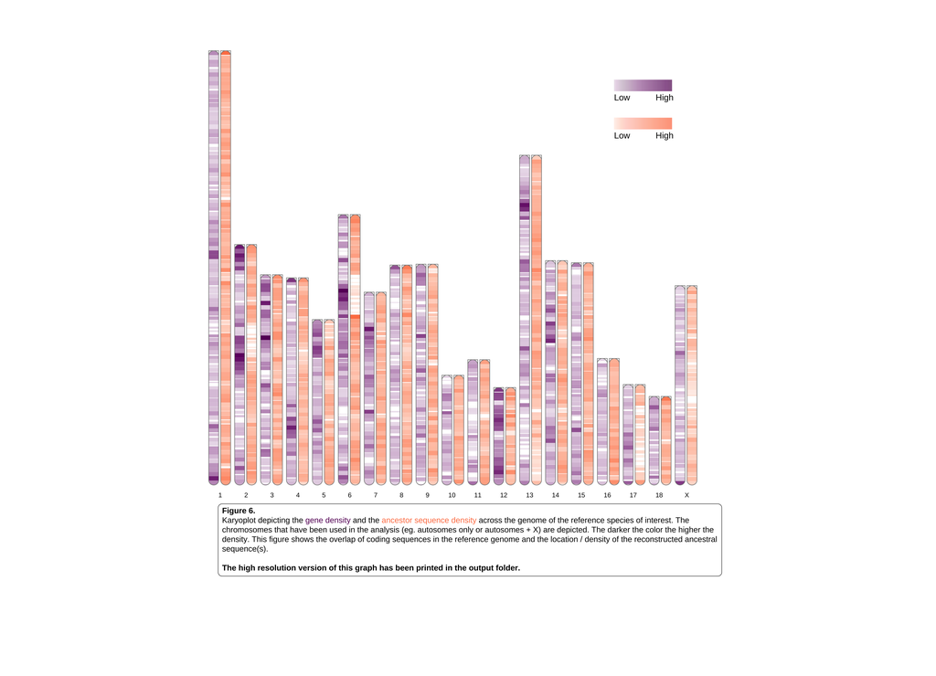

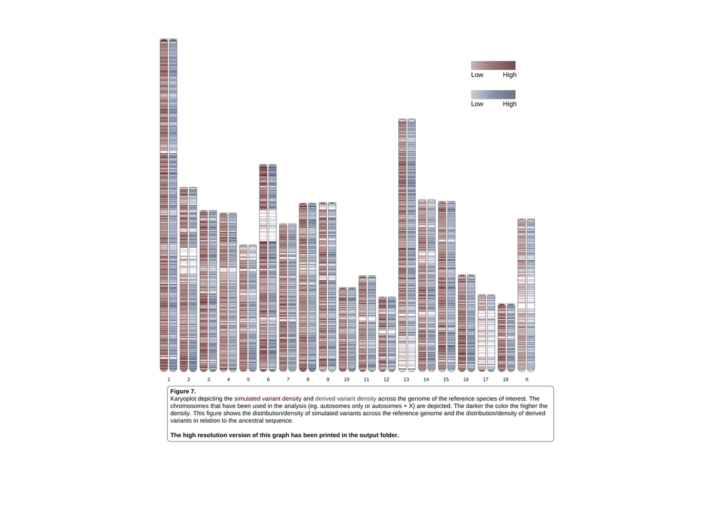

[figure not shown]

### Validation of simulation parameters

Number of mutations, fractions, and substitution rates. To make sure the simulation was performed as expected, the leftmost part is the calculated numbers and rates in the parameter files, including the total number of simulated variants per chromosome, based on information from the ancestor and reference species. The middle part is the (re)calculated numbers and rates based on the total number of simulated variants. The rightmost part is the (re)calculated numbers and rates within the subset with a corresponding non-gap ancestral sequence. The comparison of parameters and simulated variants is to make sure that the simulation has been perform as intended, and the comparison between total set and the subset is to make sure that the distribution is the same even if the variants are forced to be down-sampled due to the lack of an available ancestral sequence.

Comparison of numebr of mutations between log files and actual simulated files

[output not shown]

[output cut: 369 more lines]